# Risk Factor Analysis

## Outcome Variable

**Outcome Variable:** ever_stunted

## Predictor Variables

**Intervention Variable:** hfoodsec

**Adjustment Set:**

unadjusted

## Stratifying Variables

The analysis was stratified on these variable(s):

- agecat
- studyid
- country

## Data Summary

| agecat | studyid | country | hfoodsec | ever_stunted | n_cell | n |
| --- | --- | --- | --- | --- | --- | --- |
| 0-24 months | GMS-Nepal | NEPAL | Food Secure | 0 | 181 | 674 |
| 0-24 months | GMS-Nepal | NEPAL | Food Secure | 1 | 298 | 674 |
| 0-24 months | GMS-Nepal | NEPAL | Mildly Food Insecure | 0 | 38 | 674 |
| 0-24 months | GMS-Nepal | NEPAL | Mildly Food Insecure | 1 | 68 | 674 |
| 0-24 months | GMS-Nepal | NEPAL | Food Insecure | 0 | 26 | 674 |
| 0-24 months | GMS-Nepal | NEPAL | Food Insecure | 1 | 63 | 674 |
| 0-24 months | JiVitA-3 | BANGLADESH | Food Secure | 0 | 4441 | 17380 |
| 0-24 months | JiVitA-3 | BANGLADESH | Food Secure | 1 | 4258 | 17380 |
| 0-24 months | JiVitA-3 | BANGLADESH | Mildly Food Insecure | 0 | 2618 | 17380 |
| 0-24 months | JiVitA-3 | BANGLADESH | Mildly Food Insecure | 1 | 3167 | 17380 |
| 0-24 months | JiVitA-3 | BANGLADESH | Food Insecure | 0 | 1212 | 17380 |
| 0-24 months | JiVitA-3 | BANGLADESH | Food Insecure | 1 | 1684 | 17380 |
| 0-24 months | JiVitA-4 | BANGLADESH | Food Secure | 0 | 1143 | 5398 |
| 0-24 months | JiVitA-4 | BANGLADESH | Food Secure | 1 | 1606 | 5398 |
| 0-24 months | JiVitA-4 | BANGLADESH | Mildly Food Insecure | 0 | 812 | 5398 |
| 0-24 months | JiVitA-4 | BANGLADESH | Mildly Food Insecure | 1 | 1135 | 5398 |
| 0-24 months | JiVitA-4 | BANGLADESH | Food Insecure | 0 | 305 | 5398 |
| 0-24 months | JiVitA-4 | BANGLADESH | Food Insecure | 1 | 397 | 5398 |
| 0-24 months | MAL-ED | BANGLADESH | Food Secure | 0 | 61 | 194 |
| 0-24 months | MAL-ED | BANGLADESH | Food Secure | 1 | 100 | 194 |
| 0-24 months | MAL-ED | BANGLADESH | Mildly Food Insecure | 0 | 1 | 194 |
| 0-24 months | MAL-ED | BANGLADESH | Mildly Food Insecure | 1 | 3 | 194 |
| 0-24 months | MAL-ED | BANGLADESH | Food Insecure | 0 | 10 | 194 |
| 0-24 months | MAL-ED | BANGLADESH | Food Insecure | 1 | 19 | 194 |
| 0-24 months | MAL-ED | BRAZIL | Food Secure | 0 | 3 | 129 |
| 0-24 months | MAL-ED | BRAZIL | Food Secure | 1 | 0 | 129 |
| 0-24 months | MAL-ED | BRAZIL | Mildly Food Insecure | 0 | 7 | 129 |
| 0-24 months | MAL-ED | BRAZIL | Mildly Food Insecure | 1 | 4 | 129 |
| 0-24 months | MAL-ED | BRAZIL | Food Insecure | 0 | 84 | 129 |
| 0-24 months | MAL-ED | BRAZIL | Food Insecure | 1 | 31 | 129 |

[output cut: 168 more lines]

The following strata were considered:

- agecat: 0-24 months, studyid: GMS-Nepal, country: NEPAL
- agecat: 0-24 months, studyid: JiVitA-3, country: BANGLADESH
- agecat: 0-24 months, studyid: JiVitA-4, country: BANGLADESH
- agecat: 0-24 months, studyid: MAL-ED, country: BANGLADESH
- agecat: 0-24 months, studyid: MAL-ED, country: BRAZIL
- agecat: 0-24 months, studyid: MAL-ED, country: INDIA
- agecat: 0-24 months, studyid: MAL-ED, country: NEPAL
- agecat: 0-24 months, studyid: MAL-ED, country: PERU
- agecat: 0-24 months, studyid: MAL-ED, country: SOUTH AFRICA
- agecat: 0-24 months, studyid: NIH-Birth, country: BANGLADESH
- agecat: 0-24 months, studyid: NIH-Crypto, country: BANGLADESH
- agecat: 0-6 months, studyid: GMS-Nepal, country: NEPAL
- agecat: 0-6 months, studyid: JiVitA-3, country: BANGLADESH
- agecat: 0-6 months, studyid: JiVitA-4, country: BANGLADESH
- agecat: 0-6 months, studyid: MAL-ED, country: BANGLADESH
- agecat: 0-6 months, studyid: MAL-ED, country: BRAZIL
- agecat: 0-6 months, studyid: MAL-ED, country: INDIA
- agecat: 0-6 months, studyid: MAL-ED, country: NEPAL
- agecat: 0-6 months, studyid: MAL-ED, country: PERU
- agecat: 0-6 months, studyid: MAL-ED, country: SOUTH AFRICA
- agecat: 0-6 months, studyid: NIH-Birth, country: BANGLADESH
- agecat: 0-6 months, studyid: NIH-Crypto, country: BANGLADESH
- agecat: 6-24 months, studyid: GMS-Nepal, country: NEPAL
- agecat: 6-24 months, studyid: JiVitA-3, country: BANGLADESH
- agecat: 6-24 months, studyid: JiVitA-4, country: BANGLADESH
- agecat: 6-24 months, studyid: MAL-ED, country: BANGLADESH
- agecat: 6-24 months, studyid: MAL-ED, country: BRAZIL
- agecat: 6-24 months, studyid: MAL-ED, country: INDIA
- agecat: 6-24 months, studyid: MAL-ED, country: NEPAL
- agecat: 6-24 months, studyid: MAL-ED, country: PERU
- agecat: 6-24 months, studyid: MAL-ED, country: SOUTH AFRICA
- agecat: 6-24 months, studyid: NIH-Birth, country: BANGLADESH
- agecat: 6-24 months, studyid: NIH-Crypto, country: BANGLADESH

### Dropped Strata

Some strata were dropped due to rare outcomes:

- agecat: 0-24 months, studyid: MAL-ED, country: BANGLADESH
- agecat: 0-24 months, studyid: MAL-ED, country: BRAZIL
- agecat: 0-24 months, studyid: MAL-ED, country: INDIA
- agecat: 0-6 months, studyid: MAL-ED, country: BANGLADESH
- agecat: 0-6 months, studyid: MAL-ED, country: BRAZIL
- agecat: 0-6 months, studyid: MAL-ED, country: INDIA
- agecat: 0-6 months, studyid: MAL-ED, country: NEPAL
- agecat: 0-6 months, studyid: MAL-ED, country: SOUTH AFRICA
- agecat: 6-24 months, studyid: MAL-ED, country: BANGLADESH
- agecat: 6-24 months, studyid: MAL-ED, country: BRAZIL
- agecat: 6-24 months, studyid: MAL-ED, country: INDIA
- agecat: 6-24 months, studyid: MAL-ED, country: NEPAL

## Methods Detail

We’re interested in the causal parameters $E[Y_a]$ for all values of $a \in \mathcal{A}$. These parameters represent the mean outcome if, possibly contrary to fact, we intervened to set all units to have $A=a$. Under the randomization and positivity assumptions, these are identified by the statistical parameters $\psi_a=E_W[E_{Y|A,W}(Y|A=a,W)]$. In addition, we’re interested in the mean of $Y$, $E[Y]$ under no intervention (the observed mean). We will estimate these parameters by using SuperLearner to fit the relevant likelihood factors – $E_{Y|A,W}(Y|A=a,W)$ and $p(A=a|W)$, and then updating our likelihood fit using a joint TMLE.

For unadjusted analyses ($W=\{\}$), initial likelihoods were estimated using Lrnr_glm to estimate the simple $E(Y|A)$ and Lrnr_mean to estimate $p(A)$. For adjusted analyses, a small library containing Lrnr_glmnet, Lrnr_xgboost, and Lrnr_mean was used.

Having estimated these parameters, we will then use the delta method to estimate relative risks and attributable risks relative to a prespecified baseline level of $A$.

# Results Detail

## Results Plots

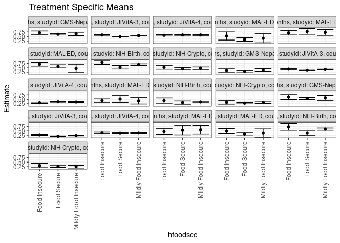

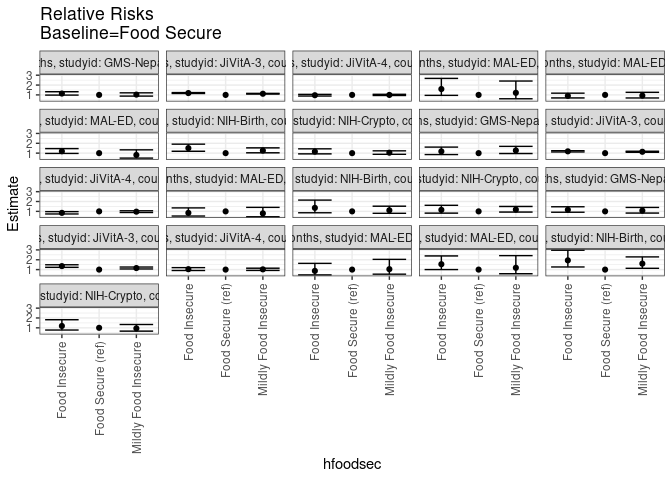

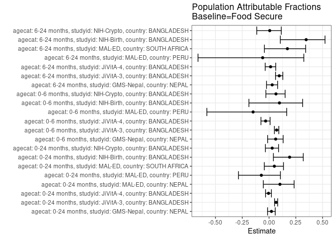

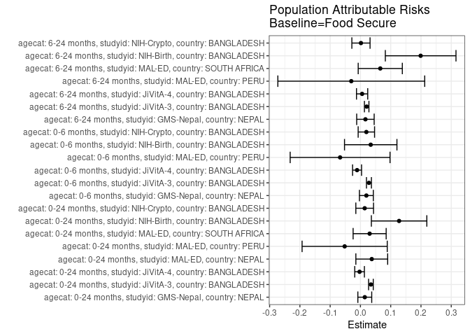

## Results Table

### Parameter: TSM

| agecat | studyid | country | intervention_level | baseline_level | estimate | ci_lower | ci_upper |
| --- | --- | --- | --- | --- | --- | --- | --- |
| 0-24 months | GMS-Nepal | NEPAL | Food Secure | NA | 0.6221294 | 0.5786769 | 0.6655819 |
| 0-24 months | GMS-Nepal | NEPAL | Mildly Food Insecure | NA | 0.6415094 | 0.5501490 | 0.7328698 |
| 0-24 months | GMS-Nepal | NEPAL | Food Insecure | NA | 0.7078652 | 0.6133193 | 0.8024110 |
| 0-24 months | JiVitA-3 | BANGLADESH | Food Secure | NA | 0.4894815 | 0.4775352 | 0.5014279 |
| 0-24 months | JiVitA-3 | BANGLADESH | Mildly Food Insecure | NA | 0.5474503 | 0.5330133 | 0.5618873 |
| 0-24 months | JiVitA-3 | BANGLADESH | Food Insecure | NA | 0.5814917 | 0.5619675 | 0.6010159 |
| 0-24 months | JiVitA-4 | BANGLADESH | Food Secure | NA | 0.5842124 | 0.5619313 | 0.6064935 |
| 0-24 months | JiVitA-4 | BANGLADESH | Mildly Food Insecure | NA | 0.5829481 | 0.5571869 | 0.6087093 |
| 0-24 months | JiVitA-4 | BANGLADESH | Food Insecure | NA | 0.5655271 | 0.5220325 | 0.6090216 |
| 0-24 months | MAL-ED | NEPAL | Food Secure | NA | 0.3297872 | 0.2343736 | 0.4252009 |
| 0-24 months | MAL-ED | NEPAL | Mildly Food Insecure | NA | 0.4000000 | 0.1511078 | 0.6488922 |
| 0-24 months | MAL-ED | NEPAL | Food Insecure | NA | 0.5263158 | 0.3009219 | 0.7517096 |
| 0-24 months | MAL-ED | PERU | Food Secure | NA | 0.7777778 | 0.6202642 | 0.9352913 |
| 0-24 months | MAL-ED | PERU | Mildly Food Insecure | NA | 0.7241379 | 0.5607440 | 0.8875319 |
| 0-24 months | MAL-ED | PERU | Food Insecure | NA | 0.7017544 | 0.5824599 | 0.8210489 |
| 0-24 months | MAL-ED | SOUTH AFRICA | Food Secure | NA | 0.5833333 | 0.4990488 | 0.6676179 |
| 0-24 months | MAL-ED | SOUTH AFRICA | Mildly Food Insecure | NA | 0.4736842 | 0.2486892 | 0.6986792 |
| 0-24 months | MAL-ED | SOUTH AFRICA | Food Insecure | NA | 0.6951220 | 0.5952672 | 0.7949767 |
| 0-24 months | NIH-Birth | BANGLADESH | Food Secure | NA | 0.5368421 | 0.4364916 | 0.6371926 |
| 0-24 months | NIH-Birth | BANGLADESH | Mildly Food Insecure | NA | 0.6768293 | 0.6354706 | 0.7181879 |
| 0-24 months | NIH-Birth | BANGLADESH | Food Insecure | NA | 0.8095238 | 0.6906725 | 0.9283752 |
| 0-24 months | NIH-Crypto | BANGLADESH | Food Secure | NA | 0.4635762 | 0.4176246 | 0.5095277 |
| 0-24 months | NIH-Crypto | BANGLADESH | Mildly Food Insecure | NA | 0.4840183 | 0.4177874 | 0.5502492 |
| 0-24 months | NIH-Crypto | BANGLADESH | Food Insecure | NA | 0.5348837 | 0.4293974 | 0.6403700 |
| 0-6 months | GMS-Nepal | NEPAL | Food Secure | NA | 0.2964509 | 0.2555224 | 0.3373795 |
| 0-6 months | GMS-Nepal | NEPAL | Mildly Food Insecure | NA | 0.3773585 | 0.2850134 | 0.4697036 |
| 0-6 months | GMS-Nepal | NEPAL | Food Insecure | NA | 0.3483146 | 0.2492587 | 0.4473705 |
| 0-6 months | JiVitA-3 | BANGLADESH | Food Secure | NA | 0.3674317 | 0.3555921 | 0.3792713 |
| 0-6 months | JiVitA-3 | BANGLADESH | Mildly Food Insecure | NA | 0.4181566 | 0.4038716 | 0.4324415 |
| 0-6 months | JiVitA-3 | BANGLADESH | Food Insecure | NA | 0.4346620 | 0.4151560 | 0.4541681 |
| 0-6 months | JiVitA-4 | BANGLADESH | Food Secure | NA | 0.3595376 | 0.3382237 | 0.3808515 |
| 0-6 months | JiVitA-4 | BANGLADESH | Mildly Food Insecure | NA | 0.3484932 | 0.3232097 | 0.3737766 |
| 0-6 months | JiVitA-4 | BANGLADESH | Food Insecure | NA | 0.3050595 | 0.2670372 | 0.3430818 |
| 0-6 months | MAL-ED | PERU | Food Secure | NA | 0.5185185 | 0.3292108 | 0.7078262 |
| 0-6 months | MAL-ED | PERU | Mildly Food Insecure | NA | 0.4137931 | 0.2337418 | 0.5938445 |
| 0-6 months | MAL-ED | PERU | Food Insecure | NA | 0.4385965 | 0.3092034 | 0.5679896 |
| 0-6 months | NIH-Birth | BANGLADESH | Food Secure | NA | 0.3157895 | 0.2222434 | 0.4093355 |
| 0-6 months | NIH-Birth | BANGLADESH | Mildly Food Insecure | NA | 0.3495935 | 0.3074253 | 0.3917617 |
| 0-6 months | NIH-Birth | BANGLADESH | Food Insecure | NA | 0.4285714 | 0.2787888 | 0.5783541 |
| 0-6 months | NIH-Crypto | BANGLADESH | Food Secure | NA | 0.2825607 | 0.2410716 | 0.3240498 |
| 0-6 months | NIH-Crypto | BANGLADESH | Mildly Food Insecure | NA | 0.3333333 | 0.2708583 | 0.3958084 |
| 0-6 months | NIH-Crypto | BANGLADESH | Food Insecure | NA | 0.3255814 | 0.2264799 | 0.4246829 |
| 6-24 months | GMS-Nepal | NEPAL | Food Secure | NA | 0.5416667 | 0.4840470 | 0.5992863 |
| 6-24 months | GMS-Nepal | NEPAL | Mildly Food Insecure | NA | 0.5833333 | 0.4436830 | 0.7229837 |
| 6-24 months | GMS-Nepal | NEPAL | Food Insecure | NA | 0.6274510 | 0.4945872 | 0.7603147 |
| 6-24 months | JiVitA-3 | BANGLADESH | Food Secure | NA | 0.1955134 | 0.1843315 | 0.2066953 |
| 6-24 months | JiVitA-3 | BANGLADESH | Mildly Food Insecure | NA | 0.2261337 | 0.2105775 | 0.2416898 |
| 6-24 months | JiVitA-3 | BANGLADESH | Food Insecure | NA | 0.2649415 | 0.2416696 | 0.2882134 |
| 6-24 months | JiVitA-4 | BANGLADESH | Food Secure | NA | 0.3718232 | 0.3459419 | 0.3977045 |
| 6-24 months | JiVitA-4 | BANGLADESH | Mildly Food Insecure | NA | 0.3809160 | 0.3496083 | 0.4122238 |
| 6-24 months | JiVitA-4 | BANGLADESH | Food Insecure | NA | 0.3878788 | 0.3400891 | 0.4356685 |
| 6-24 months | MAL-ED | PERU | Food Secure | NA | 0.5384615 | 0.2652198 | 0.8117033 |
| 6-24 months | MAL-ED | PERU | Mildly Food Insecure | NA | 0.5625000 | 0.3174088 | 0.8075912 |
| 6-24 months | MAL-ED | PERU | Food Insecure | NA | 0.4687500 | 0.2944158 | 0.6430842 |
| 6-24 months | MAL-ED | SOUTH AFRICA | Food Secure | NA | 0.3164557 | 0.2135386 | 0.4193728 |
| 6-24 months | MAL-ED | SOUTH AFRICA | Mildly Food Insecure | NA | 0.3750000 | 0.1369561 | 0.6130439 |
| 6-24 months | MAL-ED | SOUTH AFRICA | Food Insecure | NA | 0.4897959 | 0.3493391 | 0.6302527 |
| 6-24 months | NIH-Birth | BANGLADESH | Food Secure | NA | 0.3750000 | 0.2480186 | 0.5019814 |
| 6-24 months | NIH-Birth | BANGLADESH | Mildly Food Insecure | NA | 0.6029963 | 0.5442233 | 0.6617692 |
| 6-24 months | NIH-Birth | BANGLADESH | Food Insecure | NA | 0.7272727 | 0.5409010 | 0.9136444 |
| 6-24 months | NIH-Crypto | BANGLADESH | Food Secure | NA | 0.2611465 | 0.2125132 | 0.3097798 |
| 6-24 months | NIH-Crypto | BANGLADESH | Mildly Food Insecure | NA | 0.2462687 | 0.1732493 | 0.3192880 |
| 6-24 months | NIH-Crypto | BANGLADESH | Food Insecure | NA | 0.3103448 | 0.1911652 | 0.4295244 |

### Parameter: E(Y)

| agecat | studyid | country | intervention_level | baseline_level | estimate | ci_lower | ci_upper |
| --- | --- | --- | --- | --- | --- | --- | --- |
| 0-24 months | GMS-Nepal | NEPAL | NA | NA | 0.6364985 | 0.6001579 | 0.6728391 |
| 0-24 months | JiVitA-3 | BANGLADESH | NA | NA | 0.5241082 | 0.5145463 | 0.5336700 |
| 0-24 months | JiVitA-4 | BANGLADESH | NA | NA | 0.5813264 | 0.5653125 | 0.5973403 |
| 0-24 months | MAL-ED | NEPAL | NA | NA | 0.3671875 | 0.2833521 | 0.4510229 |
| 0-24 months | MAL-ED | PERU | NA | NA | 0.7256637 | 0.6430317 | 0.8082957 |
| 0-24 months | MAL-ED | SOUTH AFRICA | NA | NA | 0.6137339 | 0.5510815 | 0.6763863 |
| 0-24 months | NIH-Birth | BANGLADESH | NA | NA | 0.6645469 | 0.6276196 | 0.7014742 |
| 0-24 months | NIH-Crypto | BANGLADESH | NA | NA | 0.4775726 | 0.4419904 | 0.5131548 |
| 0-6 months | GMS-Nepal | NEPAL | NA | NA | 0.3160237 | 0.2808984 | 0.3511491 |
| 0-6 months | JiVitA-3 | BANGLADESH | NA | NA | 0.3955073 | 0.3867171 | 0.4042976 |
| 0-6 months | JiVitA-4 | BANGLADESH | NA | NA | 0.3483896 | 0.3331073 | 0.3636720 |
| 0-6 months | MAL-ED | PERU | NA | NA | 0.4513274 | 0.3591676 | 0.5434872 |
| 0-6 months | NIH-Birth | BANGLADESH | NA | NA | 0.3497615 | 0.3124631 | 0.3870600 |
| 0-6 months | NIH-Crypto | BANGLADESH | NA | NA | 0.3021108 | 0.2694011 | 0.3348205 |
| 6-24 months | GMS-Nepal | NEPAL | NA | NA | 0.5581395 | 0.5085981 | 0.6076809 |
| 6-24 months | JiVitA-3 | BANGLADESH | NA | NA | 0.2161025 | 0.2066983 | 0.2255067 |
| 6-24 months | JiVitA-4 | BANGLADESH | NA | NA | 0.3773167 | 0.3586399 | 0.3959936 |
| 6-24 months | MAL-ED | PERU | NA | NA | 0.5081967 | 0.3816986 | 0.6346949 |
| 6-24 months | MAL-ED | SOUTH AFRICA | NA | NA | 0.3819444 | 0.3023113 | 0.4615776 |
| 6-24 months | NIH-Birth | BANGLADESH | NA | NA | 0.5739130 | 0.5216565 | 0.6261696 |
| 6-24 months | NIH-Crypto | BANGLADESH | NA | NA | 0.2628458 | 0.2244546 | 0.3012371 |

### Parameter: RR

| agecat | studyid | country | intervention_level | baseline_level | estimate | ci_lower | ci_upper |
| --- | --- | --- | --- | --- | --- | --- | --- |
| 0-24 months | GMS-Nepal | NEPAL | Food Secure | Food Secure | 1.0000000 | 1.0000000 | 1.0000000 |
| 0-24 months | GMS-Nepal | NEPAL | Mildly Food Insecure | Food Secure | 1.0311511 | 0.8799026 | 1.2083980 |
| 0-24 months | GMS-Nepal | NEPAL | Food Insecure | Food Secure | 1.1378101 | 0.9786131 | 1.3229047 |
| 0-24 months | JiVitA-3 | BANGLADESH | Food Secure | Food Secure | 1.0000000 | 1.0000000 | 1.0000000 |
| 0-24 months | JiVitA-3 | BANGLADESH | Mildly Food Insecure | Food Secure | 1.1184289 | 1.0824199 | 1.1556358 |
| 0-24 months | JiVitA-3 | BANGLADESH | Food Insecure | Food Secure | 1.1879747 | 1.1432293 | 1.2344714 |
| 0-24 months | JiVitA-4 | BANGLADESH | Food Secure | Food Secure | 1.0000000 | 1.0000000 | 1.0000000 |
| 0-24 months | JiVitA-4 | BANGLADESH | Mildly Food Insecure | Food Secure | 0.9978359 | 0.9409006 | 1.0582163 |
| 0-24 months | JiVitA-4 | BANGLADESH | Food Insecure | Food Secure | 0.9680161 | 0.8882113 | 1.0549914 |
| 0-24 months | MAL-ED | NEPAL | Food Secure | Food Secure | 1.0000000 | 1.0000000 | 1.0000000 |
| 0-24 months | MAL-ED | NEPAL | Mildly Food Insecure | Food Secure | 1.2129032 | 0.6106769 | 2.4090222 |
| 0-24 months | MAL-ED | NEPAL | Food Insecure | Food Secure | 1.5959253 | 0.9518332 | 2.6758654 |
| 0-24 months | MAL-ED | PERU | Food Secure | Food Secure | 1.0000000 | 1.0000000 | 1.0000000 |
| 0-24 months | MAL-ED | PERU | Mildly Food Insecure | Food Secure | 0.9310345 | 0.6875281 | 1.2607852 |
| 0-24 months | MAL-ED | PERU | Food Insecure | Food Secure | 0.9022556 | 0.6926259 | 1.1753317 |
| 0-24 months | MAL-ED | SOUTH AFRICA | Food Secure | Food Secure | 1.0000000 | 1.0000000 | 1.0000000 |
| 0-24 months | MAL-ED | SOUTH AFRICA | Mildly Food Insecure | Food Secure | 0.8120301 | 0.4942582 | 1.3341060 |
| 0-24 months | MAL-ED | SOUTH AFRICA | Food Insecure | Food Secure | 1.1916376 | 0.9719830 | 1.4609312 |
| 0-24 months | NIH-Birth | BANGLADESH | Food Secure | Food Secure | 1.0000000 | 1.0000000 | 1.0000000 |
| 0-24 months | NIH-Birth | BANGLADESH | Mildly Food Insecure | Food Secure | 1.2607604 | 1.0356748 | 1.5347643 |
| 0-24 months | NIH-Birth | BANGLADESH | Food Insecure | Food Secure | 1.5079365 | 1.1889272 | 1.9125414 |
| 0-24 months | NIH-Crypto | BANGLADESH | Food Secure | Food Secure | 1.0000000 | 1.0000000 | 1.0000000 |
| 0-24 months | NIH-Crypto | BANGLADESH | Mildly Food Insecure | Food Secure | 1.0440965 | 0.8817787 | 1.2362939 |
| 0-24 months | NIH-Crypto | BANGLADESH | Food Insecure | Food Secure | 1.1538206 | 0.9252933 | 1.4387892 |
| 0-6 months | GMS-Nepal | NEPAL | Food Secure | Food Secure | 1.0000000 | 1.0000000 | 1.0000000 |
| 0-6 months | GMS-Nepal | NEPAL | Mildly Food Insecure | Food Secure | 1.2729205 | 0.9611164 | 1.6858798 |
| 0-6 months | GMS-Nepal | NEPAL | Food Insecure | Food Secure | 1.1749486 | 0.8564981 | 1.6118006 |
| 0-6 months | JiVitA-3 | BANGLADESH | Food Secure | Food Secure | 1.0000000 | 1.0000000 | 1.0000000 |
| 0-6 months | JiVitA-3 | BANGLADESH | Mildly Food Insecure | Food Secure | 1.1380526 | 1.0875678 | 1.1908810 |
| 0-6 months | JiVitA-3 | BANGLADESH | Food Insecure | Food Secure | 1.1829738 | 1.1204958 | 1.2489355 |
| 0-6 months | JiVitA-4 | BANGLADESH | Food Secure | Food Secure | 1.0000000 | 1.0000000 | 1.0000000 |
| 0-6 months | JiVitA-4 | BANGLADESH | Mildly Food Insecure | Food Secure | 0.9692816 | 0.8833753 | 1.0635421 |
| 0-6 months | JiVitA-4 | BANGLADESH | Food Insecure | Food Secure | 0.8484775 | 0.7387865 | 0.9744547 |
| 0-6 months | MAL-ED | PERU | Food Secure | Food Secure | 1.0000000 | 1.0000000 | 1.0000000 |
| 0-6 months | MAL-ED | PERU | Mildly Food Insecure | Food Secure | 0.7980296 | 0.4522086 | 1.4083127 |
| 0-6 months | MAL-ED | PERU | Food Insecure | Food Secure | 0.8458647 | 0.5289894 | 1.3525544 |
| 0-6 months | NIH-Birth | BANGLADESH | Food Secure | Food Secure | 1.0000000 | 1.0000000 | 1.0000000 |
| 0-6 months | NIH-Birth | BANGLADESH | Mildly Food Insecure | Food Secure | 1.1070461 | 0.8040047 | 1.5243082 |
| 0-6 months | NIH-Birth | BANGLADESH | Food Insecure | Food Secure | 1.3571429 | 0.8583327 | 2.1458308 |
| 0-6 months | NIH-Crypto | BANGLADESH | Food Secure | Food Secure | 1.0000000 | 1.0000000 | 1.0000000 |
| 0-6 months | NIH-Crypto | BANGLADESH | Mildly Food Insecure | Food Secure | 1.1796875 | 0.9297470 | 1.4968186 |
| 0-6 months | NIH-Crypto | BANGLADESH | Food Insecure | Food Secure | 1.1522529 | 0.8218241 | 1.6155365 |
| 6-24 months | GMS-Nepal | NEPAL | Food Secure | Food Secure | 1.0000000 | 1.0000000 | 1.0000000 |
| 6-24 months | GMS-Nepal | NEPAL | Mildly Food Insecure | Food Secure | 1.0769231 | 0.8287291 | 1.3994480 |
| 6-24 months | GMS-Nepal | NEPAL | Food Insecure | Food Secure | 1.1583710 | 0.9139730 | 1.4681216 |
| 6-24 months | JiVitA-3 | BANGLADESH | Food Secure | Food Secure | 1.0000000 | 1.0000000 | 1.0000000 |
| 6-24 months | JiVitA-3 | BANGLADESH | Mildly Food Insecure | Food Secure | 1.1566146 | 1.0629406 | 1.2585438 |
| 6-24 months | JiVitA-3 | BANGLADESH | Food Insecure | Food Secure | 1.3551064 | 1.2310814 | 1.4916262 |
| 6-24 months | JiVitA-4 | BANGLADESH | Food Secure | Food Secure | 1.0000000 | 1.0000000 | 1.0000000 |
| 6-24 months | JiVitA-4 | BANGLADESH | Mildly Food Insecure | Food Secure | 1.0244547 | 0.9192985 | 1.1416394 |
| 6-24 months | JiVitA-4 | BANGLADESH | Food Insecure | Food Secure | 1.0431807 | 0.9070420 | 1.1997525 |
| 6-24 months | MAL-ED | PERU | Food Secure | Food Secure | 1.0000000 | 1.0000000 | 1.0000000 |
| 6-24 months | MAL-ED | PERU | Mildly Food Insecure | Food Secure | 1.0446429 | 0.5351702 | 2.0391245 |
| 6-24 months | MAL-ED | PERU | Food Insecure | Food Secure | 0.8705357 | 0.4640367 | 1.6331303 |
| 6-24 months | MAL-ED | SOUTH AFRICA | Food Secure | Food Secure | 1.0000000 | 1.0000000 | 1.0000000 |
| 6-24 months | MAL-ED | SOUTH AFRICA | Mildly Food Insecure | Food Secure | 1.1850000 | 0.5807115 | 2.4181113 |
| 6-24 months | MAL-ED | SOUTH AFRICA | Food Insecure | Food Secure | 1.5477551 | 1.0032193 | 2.3878586 |
| 6-24 months | NIH-Birth | BANGLADESH | Food Secure | Food Secure | 1.0000000 | 1.0000000 | 1.0000000 |
| 6-24 months | NIH-Birth | BANGLADESH | Mildly Food Insecure | Food Secure | 1.6079900 | 1.1304540 | 2.2872508 |
| 6-24 months | NIH-Birth | BANGLADESH | Food Insecure | Food Secure | 1.9393939 | 1.2683556 | 2.9654529 |
| 6-24 months | NIH-Crypto | BANGLADESH | Food Secure | Food Secure | 1.0000000 | 1.0000000 | 1.0000000 |
| 6-24 months | NIH-Crypto | BANGLADESH | Mildly Food Insecure | Food Secure | 0.9430288 | 0.6644504 | 1.3384043 |
| 6-24 months | NIH-Crypto | BANGLADESH | Food Insecure | Food Secure | 1.1883936 | 0.7755412 | 1.8210244 |

### Parameter: PAR

| agecat | studyid | country | intervention_level | baseline_level | estimate | ci_lower | ci_upper |
| --- | --- | --- | --- | --- | --- | --- | --- |
| 0-24 months | GMS-Nepal | NEPAL | Food Secure | NA | 0.0143691 | -0.0085450 | 0.0372831 |
| 0-24 months | JiVitA-3 | BANGLADESH | Food Secure | NA | 0.0346266 | 0.0269263 | 0.0423269 |
| 0-24 months | JiVitA-4 | BANGLADESH | Food Secure | NA | -0.0028860 | -0.0188477 | 0.0130756 |
| 0-24 months | MAL-ED | NEPAL | Food Secure | NA | 0.0374003 | -0.0151449 | 0.0899454 |
| 0-24 months | MAL-ED | PERU | Food Secure | NA | -0.0521141 | -0.1927633 | 0.0885352 |
| 0-24 months | MAL-ED | SOUTH AFRICA | Food Secure | NA | 0.0304006 | -0.0241903 | 0.0849915 |
| 0-24 months | NIH-Birth | BANGLADESH | Food Secure | NA | 0.1277048 | 0.0360971 | 0.2193125 |
| 0-24 months | NIH-Crypto | BANGLADESH | Food Secure | NA | 0.0139964 | -0.0152237 | 0.0432165 |
| 0-6 months | GMS-Nepal | NEPAL | Food Secure | NA | 0.0195728 | -0.0034042 | 0.0425498 |
| 0-6 months | JiVitA-3 | BANGLADESH | Food Secure | NA | 0.0280756 | 0.0198905 | 0.0362608 |
| 0-6 months | JiVitA-4 | BANGLADESH | Food Secure | NA | -0.0111479 | -0.0259740 | 0.0036781 |
| 0-6 months | MAL-ED | PERU | Food Secure | NA | -0.0671911 | -0.2321305 | 0.0977483 |
| 0-6 months | NIH-Birth | BANGLADESH | Food Secure | NA | 0.0339721 | -0.0526229 | 0.1205670 |
| 0-6 months | NIH-Crypto | BANGLADESH | Food Secure | NA | 0.0195501 | -0.0075392 | 0.0466394 |
| 6-24 months | GMS-Nepal | NEPAL | Food Secure | NA | 0.0164729 | -0.0123879 | 0.0453337 |
| 6-24 months | JiVitA-3 | BANGLADESH | Food Secure | NA | 0.0205891 | 0.0131407 | 0.0280375 |
| 6-24 months | JiVitA-4 | BANGLADESH | Food Secure | NA | 0.0054935 | -0.0130533 | 0.0240403 |
| 6-24 months | MAL-ED | PERU | Food Secure | NA | -0.0302648 | -0.2728345 | 0.2123049 |
| 6-24 months | MAL-ED | SOUTH AFRICA | Food Secure | NA | 0.0654887 | -0.0073924 | 0.1383699 |
| 6-24 months | NIH-Birth | BANGLADESH | Food Secure | NA | 0.1989130 | 0.0822062 | 0.3156198 |
| 6-24 months | NIH-Crypto | BANGLADESH | Food Secure | NA | 0.0016994 | -0.0283609 | 0.0317596 |

### Parameter: PAF

| agecat | studyid | country | intervention_level | baseline_level | estimate | ci_lower | ci_upper |
| --- | --- | --- | --- | --- | --- | --- | --- |
| 0-24 months | GMS-Nepal | NEPAL | Food Secure | NA | 0.0225752 | -0.0141541 | 0.0579743 |
| 0-24 months | JiVitA-3 | BANGLADESH | Food Secure | NA | 0.0660677 | 0.0512757 | 0.0806291 |
| 0-24 months | JiVitA-4 | BANGLADESH | Food Secure | NA | -0.0049645 | -0.0328048 | 0.0221252 |
| 0-24 months | MAL-ED | NEPAL | Food Secure | NA | 0.1018560 | -0.0533699 | 0.2342077 |
| 0-24 months | MAL-ED | PERU | Food Secure | NA | -0.0718157 | -0.2852318 | 0.1061621 |
| 0-24 months | MAL-ED | SOUTH AFRICA | Food Secure | NA | 0.0495338 | -0.0440285 | 0.1347113 |
| 0-24 months | NIH-Birth | BANGLADESH | Food Secure | NA | 0.1921682 | 0.0407818 | 0.3196624 |
| 0-24 months | NIH-Crypto | BANGLADESH | Food Secure | NA | 0.0293074 | -0.0338788 | 0.0886319 |
| 0-6 months | GMS-Nepal | NEPAL | Food Secure | NA | 0.0619346 | -0.0136170 | 0.1318548 |
| 0-6 months | JiVitA-3 | BANGLADESH | Food Secure | NA | 0.0709864 | 0.0500432 | 0.0914679 |
| 0-6 months | JiVitA-4 | BANGLADESH | Food Secure | NA | -0.0319985 | -0.0754653 | 0.0097115 |
| 0-6 months | MAL-ED | PERU | Food Secure | NA | -0.1488744 | -0.5806847 | 0.1649743 |
| 0-6 months | NIH-Birth | BANGLADESH | Food Secure | NA | 0.0971292 | -0.1877192 | 0.3136629 |
| 0-6 months | NIH-Crypto | BANGLADESH | Food Secure | NA | 0.0647117 | -0.0293366 | 0.1501671 |
| 6-24 months | GMS-Nepal | NEPAL | Food Secure | NA | 0.0295139 | -0.0236989 | 0.0799607 |
| 6-24 months | JiVitA-3 | BANGLADESH | Food Secure | NA | 0.0952747 | 0.0604658 | 0.1287939 |
| 6-24 months | JiVitA-4 | BANGLADESH | Food Secure | NA | 0.0145595 | -0.0358220 | 0.0624905 |
| 6-24 months | MAL-ED | PERU | Food Secure | NA | -0.0595533 | -0.6629489 | 0.3249021 |
| 6-24 months | MAL-ED | SOUTH AFRICA | Food Secure | NA | 0.1714614 | -0.0432176 | 0.3419627 |
| 6-24 months | NIH-Birth | BANGLADESH | Food Secure | NA | 0.3465909 | 0.1055065 | 0.5226981 |
| 6-24 months | NIH-Crypto | BANGLADESH | Food Secure | NA | 0.0064652 | -0.1147404 | 0.1144922 |